# Data Analysis Final

Matthew Jusino

2022-12-17

```
## here() starts at C:/environmental_data
```

```
##    Min. 1st Qu.  Median    Mean 3rd Qu.    Max.
##    5.00   35.00   43.00   44.06   54.00  105.00
```

```
##    Min. 1st Qu.  Median    Mean 3rd Qu.    Max.
##    49.0   106.0   116.0   114.7   124.0   265.0
```

```
##
##  Shapiro-Wilk normality test
##
## data:  del$body_mass
## W = 0.99506, p-value = 4.33e-05
```

```
##
##  Shapiro-Wilk normality test
##
## data:  del$body_length
## W = 0.87609, p-value < 2.2e-16
```

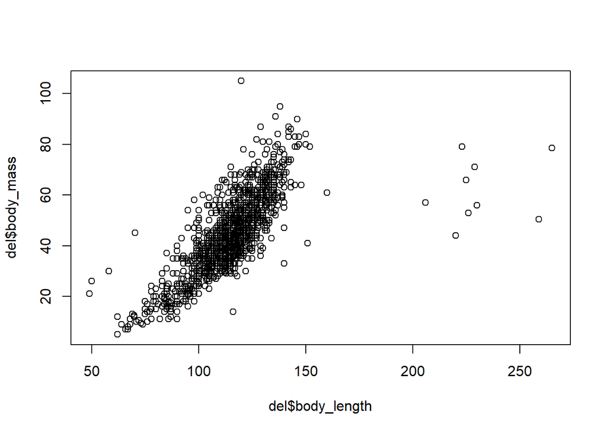

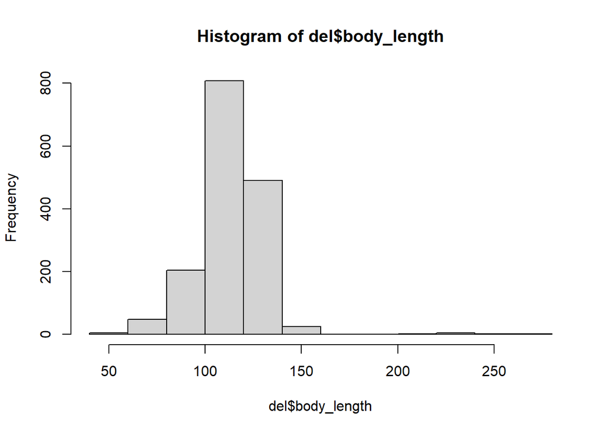

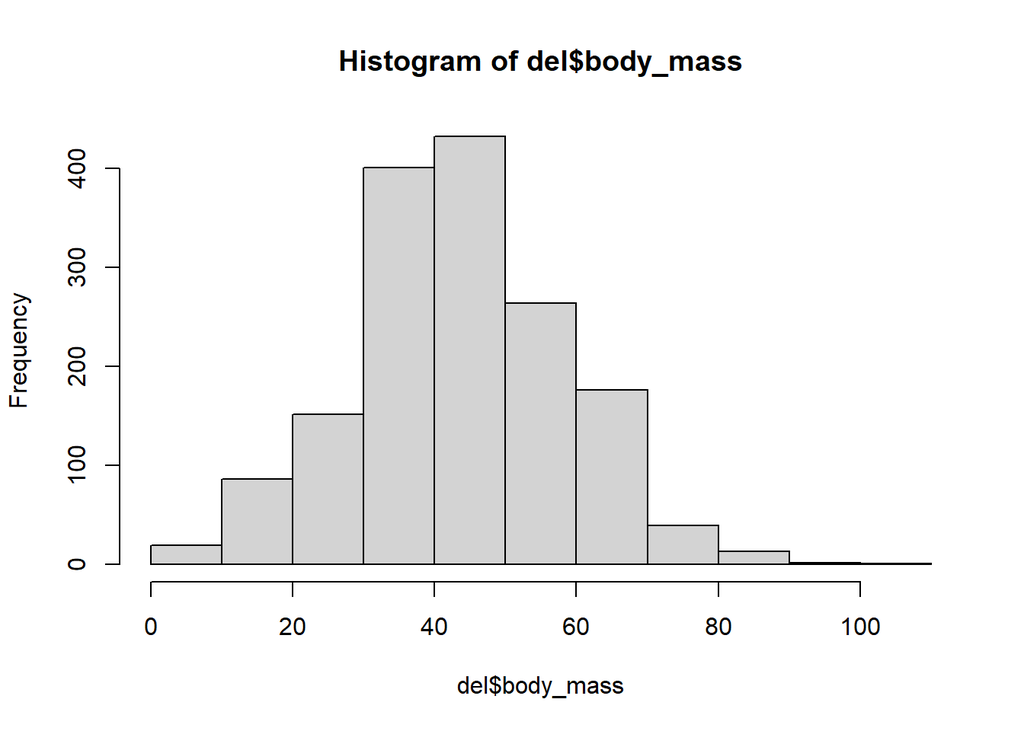

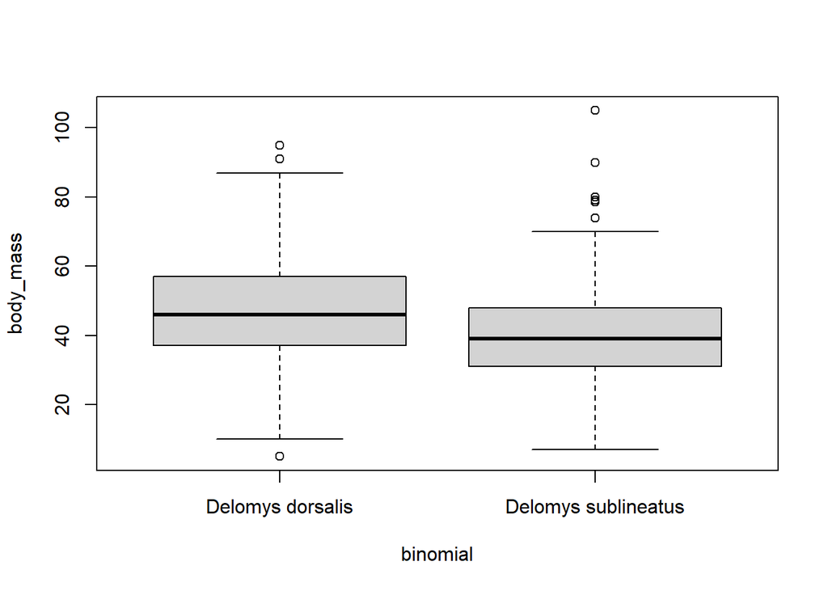

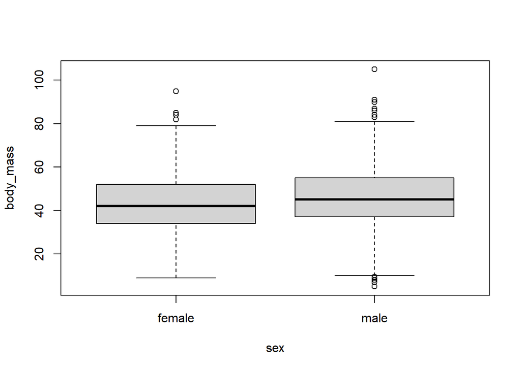

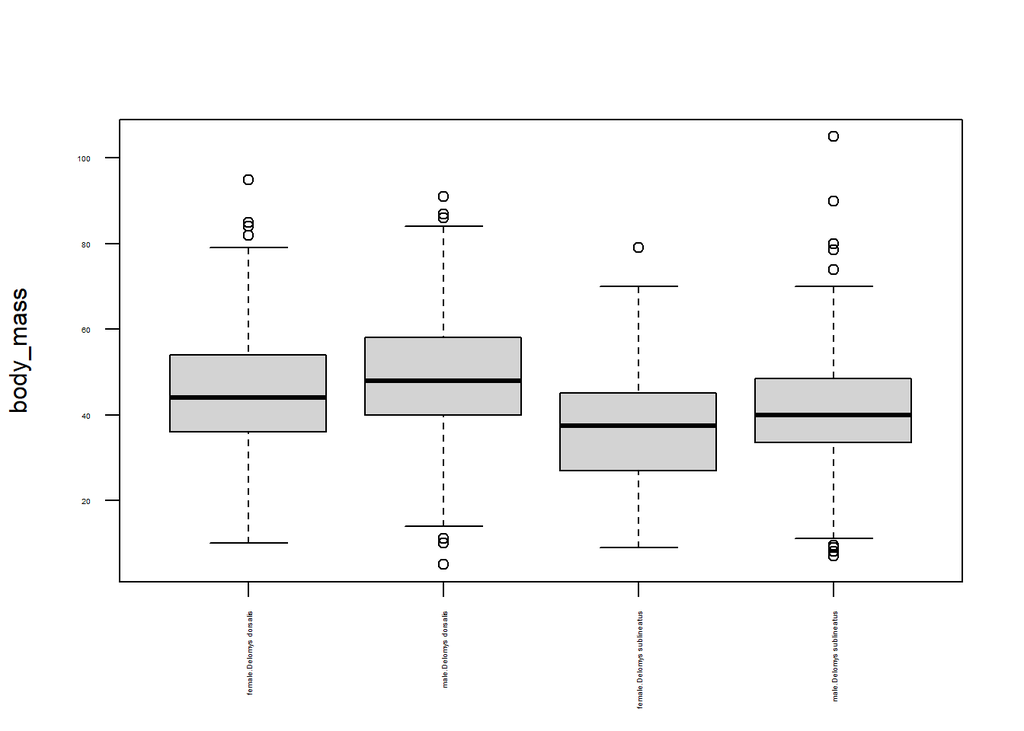

### Q1 (2 pts.): Qualitatively describe the relationship between body mass and length.

### Does the relationship seem linear, curved, nonexistent?

There seems to be a linear relationship between body mass and length.

### Q2 (2 pts.): Qualitatively describe the shapes of the histograms.

### Do the data appear normally-distributed? Explain why or why not.

### Explain why we care (or not) whether the data are normally distributed.

Neither of the histograms appear to be normally distributed. They visibly lack the distinct bell shape of a normal distribution, though body mass is closer. We don’t care because the normality assumption for ANOVA applies only to the residuals of the data.

### Q3 (2 pts.): Using both the histograms and normality tests, do you think the (unconditioned) body masses and body length are normally-distributed?

The Shapiro Tests confirm that neither are normally distributed.

### Q4 (2 pts.): Examine the three conditional boxplots.

### Describe any graphical evidence you see for body mass differences based on species and/or sex.

```
##
## Call:
## lm(formula = body_length ~ body_mass, data = del)
##
## Residuals:
##     Min      1Q  Median      3Q     Max
## -48.888  -5.398   0.104   4.859 138.663
##
## Coefficients:
##             Estimate Std. Error t value Pr(>|t|)
## (Intercept) 76.12466    0.91581   83.12   <2e-16 ***
## body_mass    0.87550    0.01969   44.46   <2e-16 ***
## ---
## Signif. codes:  0 '***' 0.001 '**' 0.01 '*' 0.05 '.' 0.1 ' ' 1
##
## Residual standard error: 11.67 on 1583 degrees of freedom
## Multiple R-squared:  0.5553, Adjusted R-squared:  0.5551
## F-statistic:  1977 on 1 and 1583 DF,  p-value: < 2.2e-16
```

```
##
##  Shapiro-Wilk normality test
##
## data:  residuals(fit1)
## W = 0.73462, p-value < 2.2e-16
```

```
##               Df Sum Sq Mean Sq F value   Pr(>F)
## sex            1   3062  3061.7   13.94 0.000195 ***
## Residuals   1578 346507   219.6
## ---
## Signif. codes:  0 '***' 0.001 '**' 0.01 '*' 0.05 '.' 0.1 ' ' 1
## 5 observations deleted due to missingness
```

```
##
##  Shapiro-Wilk normality test
##
## data:  residuals(fit2)
## W = 0.99563, p-value = 0.0001541
```

```
##               Df Sum Sq Mean Sq F value Pr(>F)
## binomial       1  21290   21290   102.1 <2e-16 ***
## Residuals   1583 330164     209
## ---
## Signif. codes:  0 '***' 0.001 '**' 0.01 '*' 0.05 '.' 0.1 ' ' 1
```

```
##
##  Shapiro-Wilk normality test
##
## data:  residuals(fit3)
## W = 0.99535, p-value = 8.103e-05
```

```
##               Df Sum Sq Mean Sq F value   Pr(>F)
## sex            1   3062    3062   14.96 0.000114 ***
## binomial       1  23727   23727  115.92  < 2e-16 ***
## Residuals   1577 322780     205
## ---
## Signif. codes:  0 '***' 0.001 '**' 0.01 '*' 0.05 '.' 0.1 ' ' 1
## 5 observations deleted due to missingness
```

```
##
##  Shapiro-Wilk normality test
##
## data:  residuals(fit4)
## W = 0.99525, p-value = 6.805e-05
```

```
##                Df Sum Sq Mean Sq F value   Pr(>F)
## sex             1   3062    3062  14.949 0.000115 ***
## binomial        1  23727   23727 115.850  < 2e-16 ***
## sex:binomial    1      1       1   0.004 0.950442
## Residuals    1576 322779     205
## ---
## Signif. codes:  0 '***' 0.001 '**' 0.01 '*' 0.05 '.' 0.1 ' ' 1
## 5 observations deleted due to missingness
```

```
##
##  Shapiro-Wilk normality test
##
## data:  residuals(fit5)
## W = 0.99526, p-value = 6.816e-05
```

### Q6 (1 pt.): Are violations of the normality assumption equally severe for all the models?

The violations are severe for all of the models. The closest to the threshold p-value of 0.05 is fit2 with a p-value of 0.0001541.

|  | Estimate | Std. Error | t value | Pr(>\|t\|) |
| --- | --- | --- | --- | --- |
| (Intercept) | 76.1246565 | 0.9158120 | 83.12258 | 0 |
| body_mass | 0.8754988 | 0.0196905 | 44.46298 | 0 |

### Q7 (2 pts.): What is the magnitude of the mass/length relationship?

The magnitude of the mass/length relationship is 0.875

### Q9 (2 pts.): What is the expected body length of an animal that weighs 0g?

|  | x |
| --- | --- |
| (Intercept) | 42.711465 |
| sexmale | 2.784133 |

|  | x |
| --- | --- |
| (Intercept) | 46.752427 |
| binomialDelomys sublineatus | -7.683058 |

|  | x |
| --- | --- |
| (Intercept) | 45.070355 |
| sexmale | 3.795395 |
| binomialDelomys sublineatus | -8.193492 |

|  | x |
| --- | --- |
| (Intercept) | 45.0554562 |
| sexmale | 3.8280908 |
| binomialDelomys sublineatus | -8.1417394 |
| sexmale:binomialDelomys sublineatus | -0.0950187 |

### Q10 (1 pt.): What is the base level for sex?

The base level for sex is female

### Q11 (1 pt.): What is the base level for binomial?

The base level for binomial is D.dorsalis

### Q12 (1 pt.): Which sex is heavier? How do you know?

Males are heavier, as their coefficient is positive, meaning their mass value is greater than the base case (female).

### Q13 (1 pt.): Which species is heavier? How do you know?

D.dorsalis is heavier, as the D.sublineatus coefficient is negative, meaning their mass value is less than the base case (D.Dorsalis).

|  | Df | Sum Sq | Mean Sq | F value | Pr(>F) |
| --- | --- | --- | --- | --- | --- |
| sex | 1 | 3061.678 | 3061.6779 | 13.94294 | 0.0001951 |
| Residuals | 1578 | 346507.131 | 219.5863 | NA | NA |

|  | Df | Sum Sq | Mean Sq | F value | Pr(>F) |
| --- | --- | --- | --- | --- | --- |
| binomial | 1 | 21289.68 | 21289.6805 | 102.0751 | 0 |
| Residuals | 1583 | 330164.45 | 208.5688 | NA | NA |

|  | Df | Sum Sq | Mean Sq | F value | Pr(>F) |
| --- | --- | --- | --- | --- | --- |
| sex | 1 | 3061.678 | 3061.6779 | 14.95838 | 0.0001144 |
| binomial | 1 | 23727.134 | 23727.1342 | 115.92320 | 0.0000000 |
| Residuals | 1577 | 322779.997 | 204.6798 | NA | NA |

|  | Df | Sum Sq | Mean Sq | F value | Pr(>F) |
| --- | --- | --- | --- | --- | --- |
| sex | 1 | 3.061678e+03 | 3.061678e+03 | 14.948932 | 0.0001150 |
| binomial | 1 | 2.372713e+04 | 2.372713e+04 | 115.849977 | 0.0000000 |
| sex:binomial | 1 | 7.913846e-01 | 7.913846e-01 | 0.003864 | 0.9504424 |
| Residuals | 1576 | 3.227792e+05 | 2.048091e+02 | NA | NA |

### Q14 (1 pt.): Are sex and species significant predictors for body mass?

Both are significant predictors for body mass

### Q15 (1 pt.): Is there a significant interaction?

There is not a significant interaction between the two, as the F-value is very small.

### Q16 (2 pts.): Examine the p-values for the main effects (sex and species) in all four of the ANOVA tables. Does the significance level of either main effect change very much among the different models?

The significance level of either main effect does not change significantly among the different models. Only minor changes on the order of 0.00008

```
## [1] 12291.67
```

```
## [1] 13006.8
```

```
## [1] 12966.36
```

```
## [1] 12896.73
```

```
## [1] 12898.72
```

### Q17 (1 pt.): Which two models have the lowest AIC?

### Q18 (4 pts.): Which of the two models with lowest AIC scores would you select?

### Explain your decision based on model fit and the complexity/understanding tradeoff.